# 시간의지평_7차_실습코드

## 논문분석

추가적으로 prophet 모형을 활용한 논문을 찾아 분석해보았다. ’K-Means 클러스터링과 Prophet 모형을 이용한 서울특별시 미세먼지 농도 예측’이라는 논문을 분석하였으며 아래에서 확인할 수 있다. https://www-dbpia-co-kr.sproxy.hufs.ac.kr/journal/articleDetail?nodeId=NODE11553696

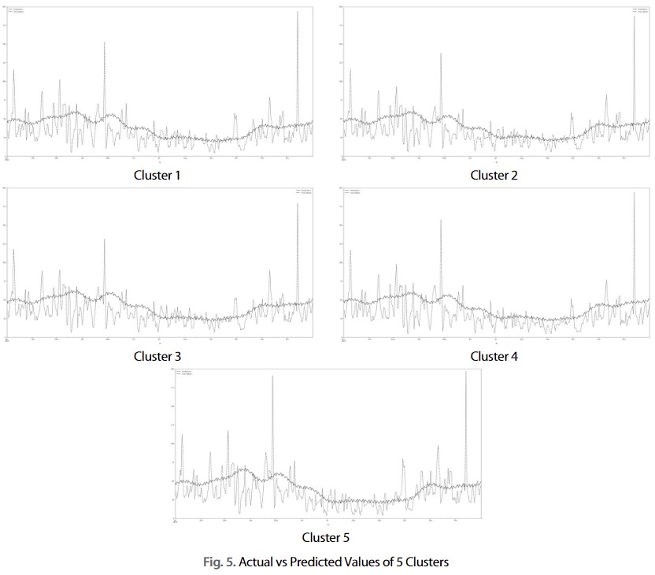

```r
knitr::include_graphics('C:\\Users\\bumbk\\OneDrive\\바탕 화면\\영준\\DAT\\시계열\\미세먼지 논문 예측 image.jpg')
```

실제 데이터와 비교하여 RMSE와 RMSPE 값을 확인한 결과는 Table 2와 같다.

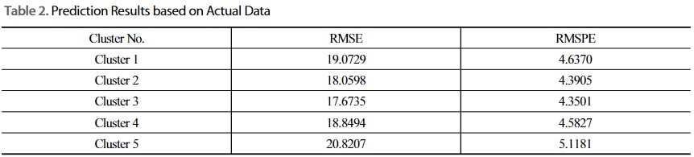

```r
knitr::include_graphics('C:\\Users\\bumbk\\OneDrive\\바탕 화면\\영준\\DAT\\시계열\\미세먼지 논문 실제 데이터와 비교.jpg')
```